# Univariate Data Visualization

**a plot to visualize the amount of user types**

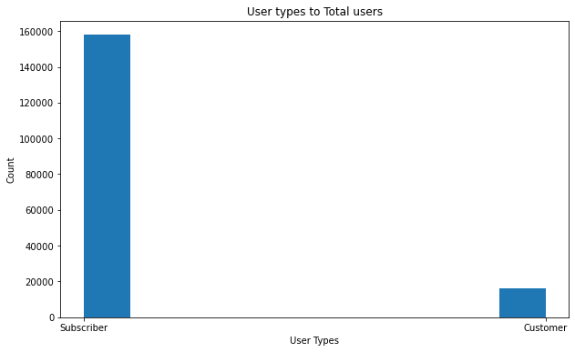

**this shows the huge difference between user types, which means the majority of users are subscribers**

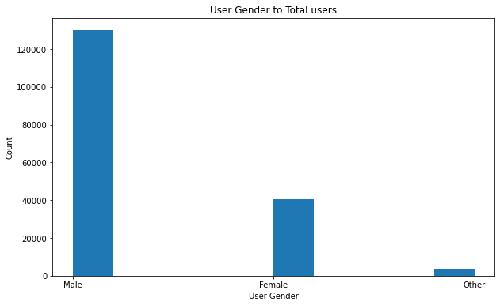

aplot between **users genders and total users** **this shows the majority of users are males**

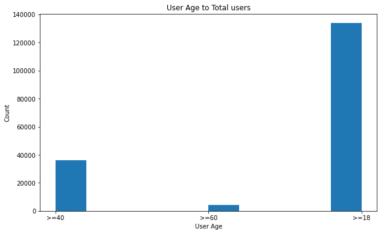

**a plot of users age vs total users**

**This is particularly odd; the majority of users are between the age 18 - 60, this maybe due to the fact that the stations do not rent bikes to users whose ages less than 18 users maybe because they do not have personal ids**

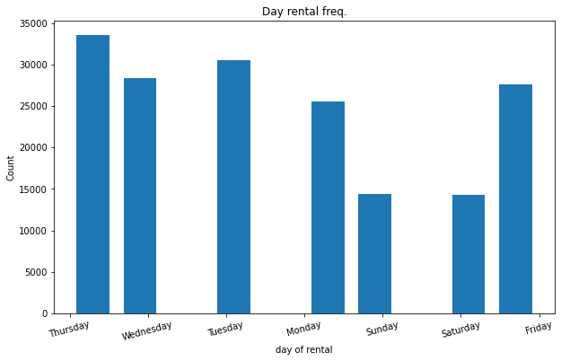

**a plot of frequency of rentals per day**

**it looks like that the highest amount of rentals was in thursday, then tuesday**

# Bivariate Data Visualization

we can start off by comparing between the age and the duration of rental

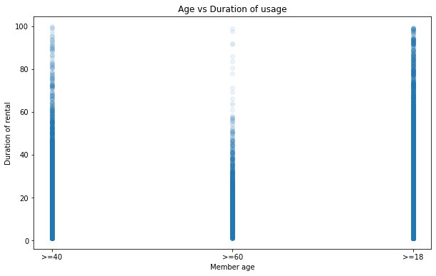

**it looks that the age category that spends the most riding the bikes are the '>=18' group which is kinda legitimate**

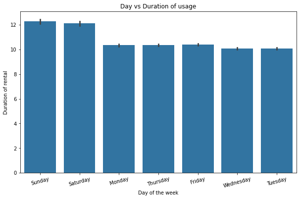

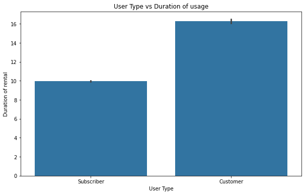

the most amount of time spe riding bikes is from the customers type, which is kinda **surprising** because the amount of customer users compared to the subscriber users is **too small**, maybe this is telling us that the subscriber type users are using the bikes to do some **usual chores** that do not span that **big amount of distance** compared to the customer type users who might use the bikes for more far distened locations.Or maybe this is due to some **outliers** in the customer user type.

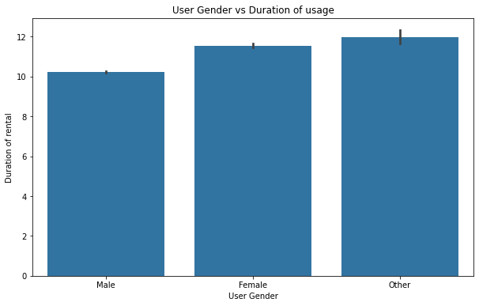

**this is surprising bit it maybe due to some outliers that made the 'other' gender the dominant in the plot, needs further invistigation maybe remove the outlier from data frame**

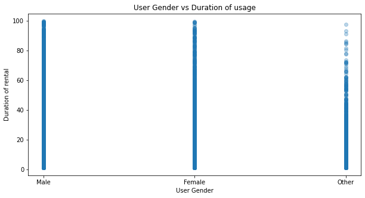

**this shows that actually the most amount of points are in the male and female genders but, the other gender has a lot of outliers which caused the confusion in the previous plot**

# Multivariate Data Visualization

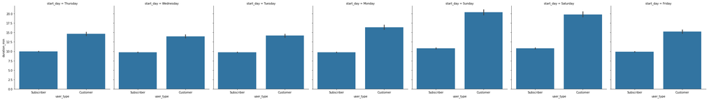

It seems like that the customer type is dominant through out the week ,which means that customer type users use the bikes for longer distances in general but not as frequent as the subscriber type users.

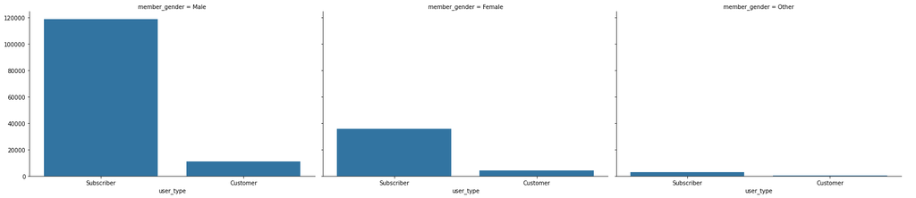

**the dominat type is subscriber and it is very obvious in the male category as they are the biggest category in this dataset**

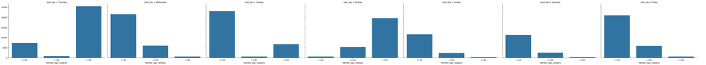